# EH550 - Lab3: Ridge/LASSO/Elastic Net regression

January 21, 2021

# 1.Fitting Elastic Net in R/Stata/SAS

Lasso/ridge/elastic net are available in SAS PROC GLMSELECT (http://support.sas.com/documentation/cdl/en/statug/67523/HTML/default/viewer.htm#statug_glmselect_details12.htm) and in the Stata command `elasticregress` (https://www.statalist.org/forums/forum/general-stata-discussion/general/1410310-new-stata-command-for-lasso-ridge-regression-and-elastic-net-regression). As for R, we will focus on the procedure implemented in the `glmnet` library, even though several alternatives are available.

# 2. Data Import and management

We are using the same dataset we used for Labs 1-2, so you may not need to reopen the dataset. In addition to opening the data, the following lines also create a dichotomous version of the outcome (again, this was used for Lab 1, so you may not want to replicate the code if you are using a single script). For simplicity we are also creating two objects X and Y containing the matrix of exposures and the outcome, respectively

```r
# load required packages
library(readxl)
library(glmnet)
library(dplyr)
library(stargazer)
set.seed(123)

# import the dataset

data2 <- read_excel("~/Dropbox/Teaching/Environmental Mixtures/2021_EH550/labs/dataset2xls.xls")



# define exposures and outcome
X<-as.matrix(data2[,3:16])
Y<-data2$y
```

# 3. Shrinkage methods

## Ridge regression

Both ridge and lasso are special cases of elastic net (respectively, with $\alpha=0$ and $\alpha=1$). We are therefore going to use the `glmnet` package for all 3 approaches. We first define a set of potential values of $\lambda$.

```r
lambdas_to_try <- 10^seq(-3, 5, length.out = 100)
```

### Lambda selection

To select the best model it is recommended to use 10-fold cross validation, which can be conducted with the `cv.glmnet` command. Note the option `standardize=TRUE` and the option `alpha=0`.

```r
ridge_cv <- cv.glmnet(X, Y, alpha = 0, lambda = lambdas_to_try,
                      standardize = TRUE, nfolds = 10)
```

By plotting the MSE we can evaluate the optimal value for $\lambda$.

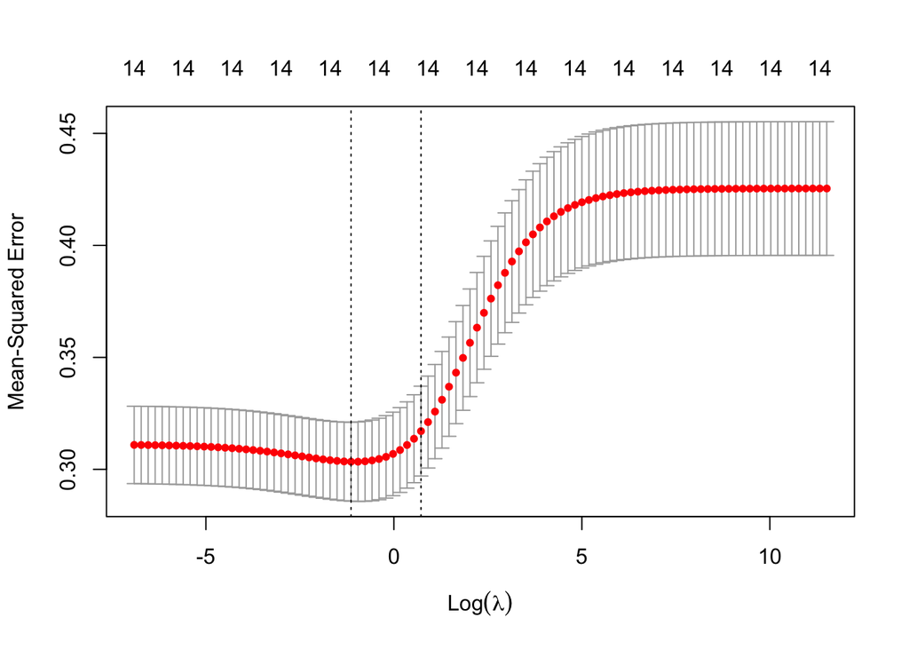

```r
plot(ridge_cv)
```

```r
# lowest lambda
lambda_cv_min <- ridge_cv$lambda.min
# Best cross-validated lambda
lambda_cv <- ridge_cv$lambda.1se
lambda_cv
```

```
## [1] 2.056512
```

The first dashed line represents the lowest $\lambda$. However, we tend to select the $\lambda$ corresponding to the second dashed line, which represents the largest $\lambda$ within 1 standard error of the minimum. This is to avoid the machine learning procedure to be overfitting (in the ML terminology, this means that the algorithm is optimal for your data but not very generalizable).

### Fitting the model

We can now fit the model for the selected $\lambda$, as well as with all investigated values to see the trajectory of coefficients.

```r
model_cv <- glmnet(X, Y, alpha = 0, lambda = lambda_cv, standardize = TRUE)
summary(model_cv$beta)
```

| i | j | x |
| --- | --- | --- |
| 1 | 1 | 0.01470466 |
| 2 | 1 | 0.02311121 |
| 3 | 1 | 0.02548302 |
| 4 | 1 | 0.02631525 |
| 5 | 1 | 0.02143848 |
| 6 | 1 | 0.02760439 |
| 7 | 1 | 0.02997202 |
| 8 | 1 | 0.03343880 |
| 9 | 1 | 0.03154066 |
| 10 | 1 | 0.02778430 |

[output cut: 4 more lines]

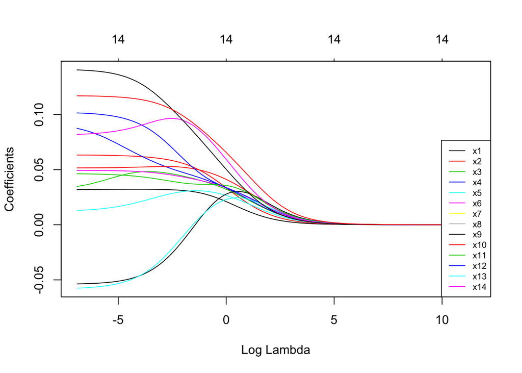

```r
res <- glmnet(X, Y, alpha = 0, lambda = lambdas_to_try, standardize = TRUE)
plot(res, xvar = "lambda")
legend("bottomright", lwd = 1, col = 1:14, legend = colnames(X), cex = .7)
```

Ridge regression provides useful information on what direction did the high variance push coefficients. For example, $X_{13}$ showed a negative coefficient because of its high correlation with $X_{12}$, but the actual value becomes positive with some additional penalty. In our context, we are using these methods for variable selection, to hopefully exclude some covariates with high correlation. To this end, Lasso may represent a better approach.

## Lasso

For Lasso, we will fit the same procedure, but setting $\alpha=1$

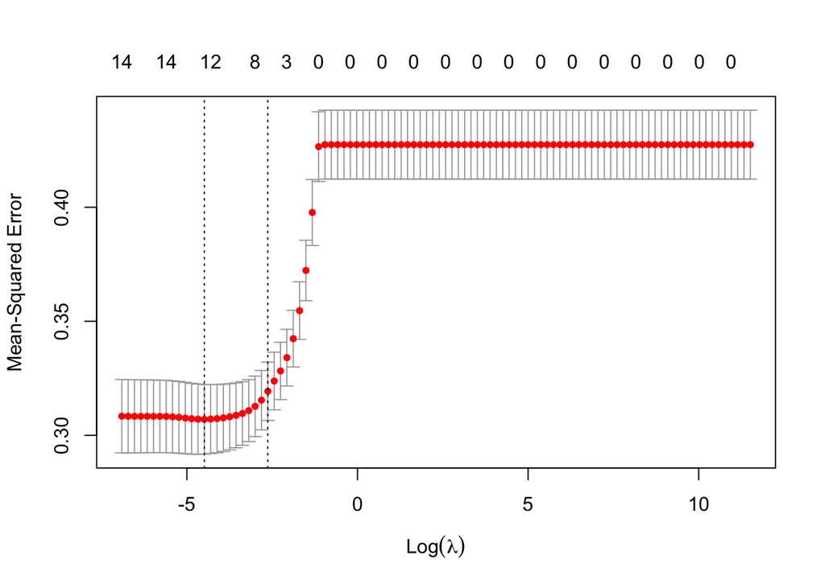

```r
lasso_cv <- cv.glmnet(X, Y, alpha = 1, lambda = lambdas_to_try,
                      standardize = TRUE, nfolds = 10)

plot(lasso_cv)
```

```r
# lowest lambda
lambda_cv_min_lasso <- lasso_cv$lambda.min
# Best cross-validated lambda
lambda_cv_lasso <- lasso_cv$lambda.1se
lambda_cv_lasso
```

```
## [1] 0.07220809
```

```r
model_cv_lasso <- glmnet(X, Y, alpha = 1, lambda = lambda_cv_lasso, standardize = TRUE)
summary(model_cv_lasso$beta)
```

| i | j | x |
| --- | --- | --- |
| 2 | 1 | 0.01159519 |
| 4 | 1 | 0.09303132 |
| 6 | 1 | 0.02107868 |
| 8 | 1 | 0.04830091 |
| 9 | 1 | 0.01002533 |
| 12 | 1 | 0.04362410 |
| 14 | 1 | 0.12429738 |

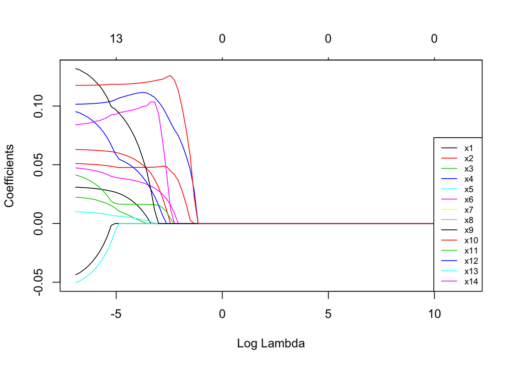

```r
res_lasso <- glmnet(X, Y, alpha = 1, lambda = lambdas_to_try, standardize = TRUE)
plot(res_lasso, xvar = "lambda")
legend("bottomright", lwd = 1, col = 1:14, legend = colnames(X), cex = .7)
```

## Elastic net

To fit elastic net, we only have to specify $\alpha$ somewhere between 0 and 1

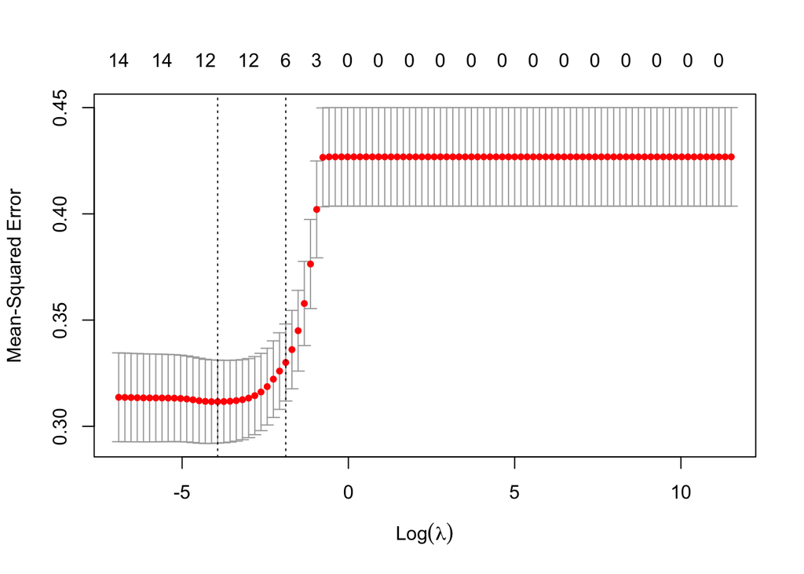

```r
enet_cv <- cv.glmnet(X, Y, alpha = 0.7, lambda = lambdas_to_try,
                     standardize = TRUE, nfolds = 10)
plot(enet_cv)
```

```r
# lowest lambda
lambda_cv_min_enet <- enet_cv$lambda.min
# Best cross-validated lambda
lambda_cv_enet <- enet_cv$lambda.1se
lambda_cv_enet
```

```
## [1] 0.1519911
```

```r
model_cv_enet <- glmnet(X, Y, alpha = 0.7, lambda = lambda_cv_enet, standardize = TRUE)
summary(model_cv_enet$beta)
```

| i | j | x |
| --- | --- | --- |
| 3 | 1 | 0.020967238 |
| 4 | 1 | 0.046578413 |
| 5 | 1 | 0.009084185 |
| 6 | 1 | 0.012364245 |
| 8 | 1 | 0.043028663 |
| 14 | 1 | 0.109816837 |

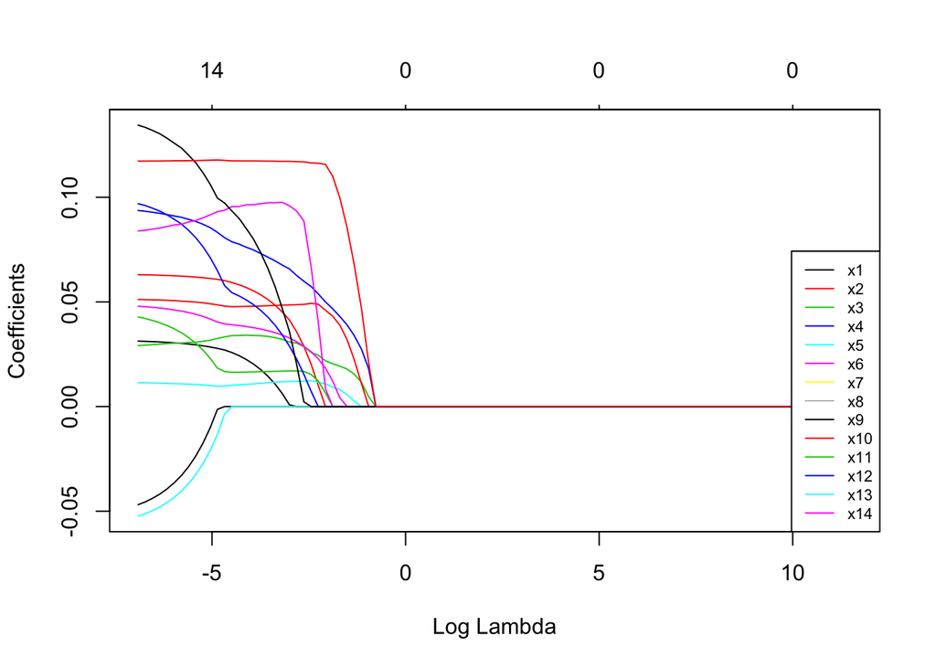

```r
res_enet <- glmnet(X, Y, alpha = 0.7, lambda = lambdas_to_try, standardize = TRUE)
plot(res_enet, xvar = "lambda")
legend("bottomright", lwd = 1, col = 1:14, legend = colnames(X), cex = .7)
```

## Adjusting for confounders

Including confounders could be done by specifying them in the model as we do in a regular OLS model. However, we may want them to be involved in the selection process. To such end, the best way is to include them in the matrix of covariates to be penalized, but inform the CV procedure that you don’t want their coefficients to be modified.

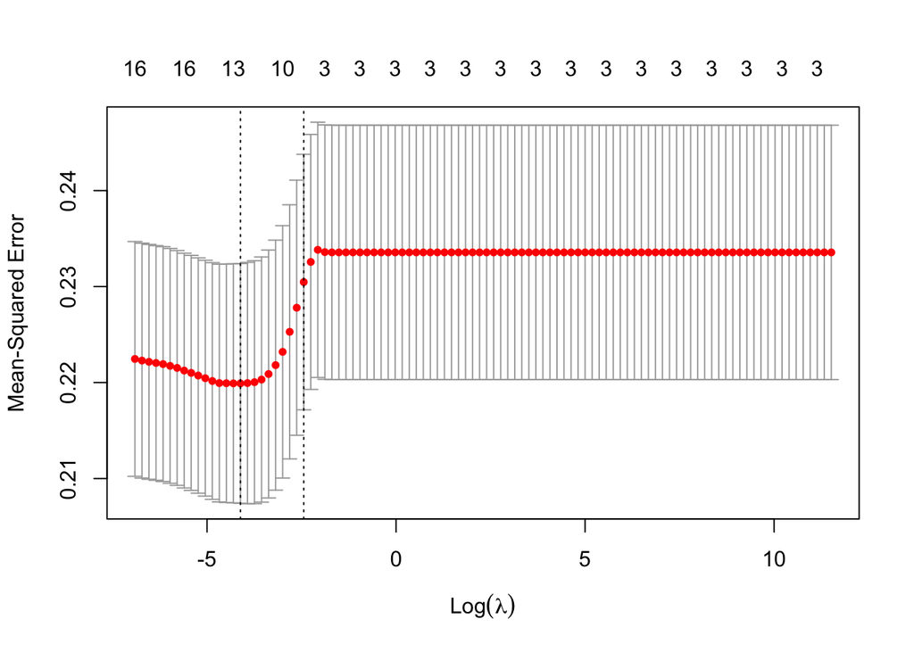

```r
X<-as.matrix(data2[,3:19])

enet_cv <- cv.glmnet(X, Y, alpha = 0.6, lambda = lambdas_to_try,
                     standardize = TRUE, nfolds = 10, penalty.factor=c(rep(1,ncol(X) - 3),0,0,0))
plot(enet_cv)
```

```r
# lowest lambda
lambda_cv_min_enet <- enet_cv$lambda.min
# Best cross-validated lambda
lambda_cv_enet <- enet_cv$lambda.1se
lambda_cv_enet
```

```
## [1] 0.0869749
```

```r
model_cv_enet <- glmnet(X, Y, alpha = 0.6, lambda = lambda_cv_enet, standardize = TRUE,penalty.factor=c(rep(1,ncol(X) - 3),0,0,0))
summary(model_cv_enet$beta)
```

| i | j | x |
| --- | --- | --- |
| 6 | 1 | 0.009916410 |
| 9 | 1 | 0.008285062 |
| 10 | 1 | 0.002294446 |
| 12 | 1 | 0.076544241 |
| 15 | 1 | -0.008572634 |
| 16 | 1 | 0.011849480 |
| 17 | 1 | -0.634827025 |

In addition to the 3 confounders (now named $X_{15}-X_{17}$) only 4 covariates did not drop to 0. Interestingly, we are now selecting none of the 3 covariates we wanted to distinguish. At the same time, it is interesting to notice that the 4 covariates that are left in the model are not the same 4 covariates that WQS suggested as most important. In particular, $X_9$ was ranked 11 out of 14. Nevertheless, results across methods seem to agree in indicating $X_6$ and $X_{12}$ as the main predictors of the outcome.

## Replicate results in OLS regression model

These are the results from a OLS regression that only includes the selected covariates, which we can compare to the multiple regression from lab 1

```r
lmall <- lm(y ~ x1+x2+x3+x4+x5+x6+x7+x8+x9+x10+x11+x12+x13+x14 + z1 + z2 + z3, data = data2)
lmselected <- lm(y ~ x6+x9+x10+x12 + z1 + z2 + z3, data = data2)
summary(lmselected)$coef
```

```
##                 Estimate  Std. Error     t value      Pr(>|t|)
## (Intercept)  3.476275239 0.104127862  33.3846790 1.618291e-128
## x6           0.085099701 0.027366958   3.1095784  1.982169e-03
## x9           0.014639395 0.049000870   0.2987579  7.652510e-01
## x10          0.085215376 0.033902851   2.5135165  1.227176e-02
## x12          0.223530830 0.076538410   2.9205053  3.655084e-03
## z1           0.003080379 0.013519730   0.2278432  8.198628e-01
## z2           0.008904362 0.001229655   7.2413477  1.722960e-12
## z3          -0.617293561 0.042367683 -14.5699156  3.103319e-40
```

```r
stargazer(lmselected, lmall, title="Results", align=TRUE, type="text")
```

```
##
## Results
## ====================================================================
##                                   Dependent variable:
##                     ------------------------------------------------
##                                            y
##                               (1)                     (2)
## --------------------------------------------------------------------
## x1                                                   0.058*
##                                                     (0.033)
##
## x2                                                   0.018
##                                                     (0.031)
##
## x3                                                   -0.030
##                                                     (0.103)
##
## x4                                                   0.053
##                                                     (0.114)
##
## x5                                                   0.004
##                                                     (0.043)
##
## x6                         0.085***                 0.060**
##                             (0.027)                 (0.030)
##
## x7                                                   -0.031
##                                                     (0.062)
##
## x8                                                   0.017
##                                                     (0.041)
##
## x9                           0.015                   0.025
##                             (0.049)                 (0.059)
##
## x10                         0.085**                  0.052
##                             (0.034)                 (0.047)
##
## x11                                                  0.049
##                                                     (0.052)
```

[output cut: 15 more lines]

```
##
## z3                         -0.617***               -0.609***
##                             (0.042)                 (0.044)
##
## Constant                   3.476***                 3.265***
##                             (0.104)                 (0.237)
##
## --------------------------------------------------------------------
## Observations                  500                     500
## R2                           0.501                   0.512
## Adjusted R2                  0.494                   0.495
## Residual Std. Error    0.464 (df = 492)         0.464 (df = 482)
## F Statistic         70.663*** (df = 7; 492) 29.779*** (df = 17; 482)
## ====================================================================
## Note:                                    *p<0.1; **p<0.05; ***p<0.01
```

Further discussion on results comparison across methods will be presented in the slides.